# Nodes and Connections

Jonathan Zhang

6/18/2019

## Task 1

- Initialize 1000 nodes in a data structure
- Using a binary system, make connections between nodes with a success rate of 5%
  - 1 means that a connection is present between two nodes
  - 0 means that there is no connection
- Plot a histogram of each node’s number of connections
  - Make observations about the distribution

The following plot is meant to visualize the 1000 nodes (not representative of real values).

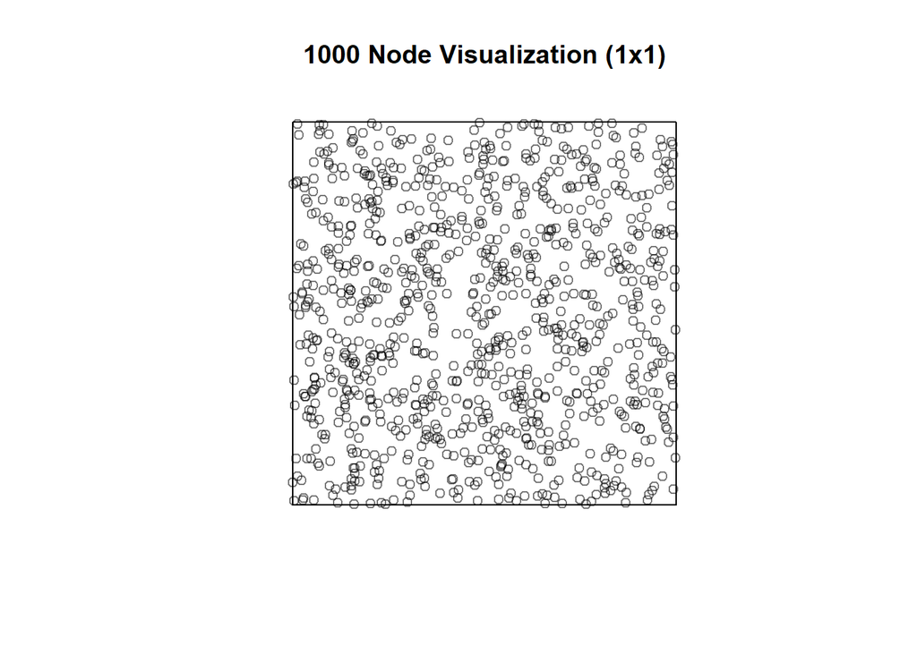

### Generating the Matrix

```r
mat = matrix(runif(1000000),1000)
for(row in 1:nrow(mat)) {
  for(col in row:ncol(mat)) {
      if (mat[row,col] < 0.05 && row != col){
        mat[row,col] = 1
        mat[col,row] = 1
      } else {
        mat[row,col] = 0
        mat[col,row] = 0
      }
  }
}
```

### Generating the Histogram of Connections

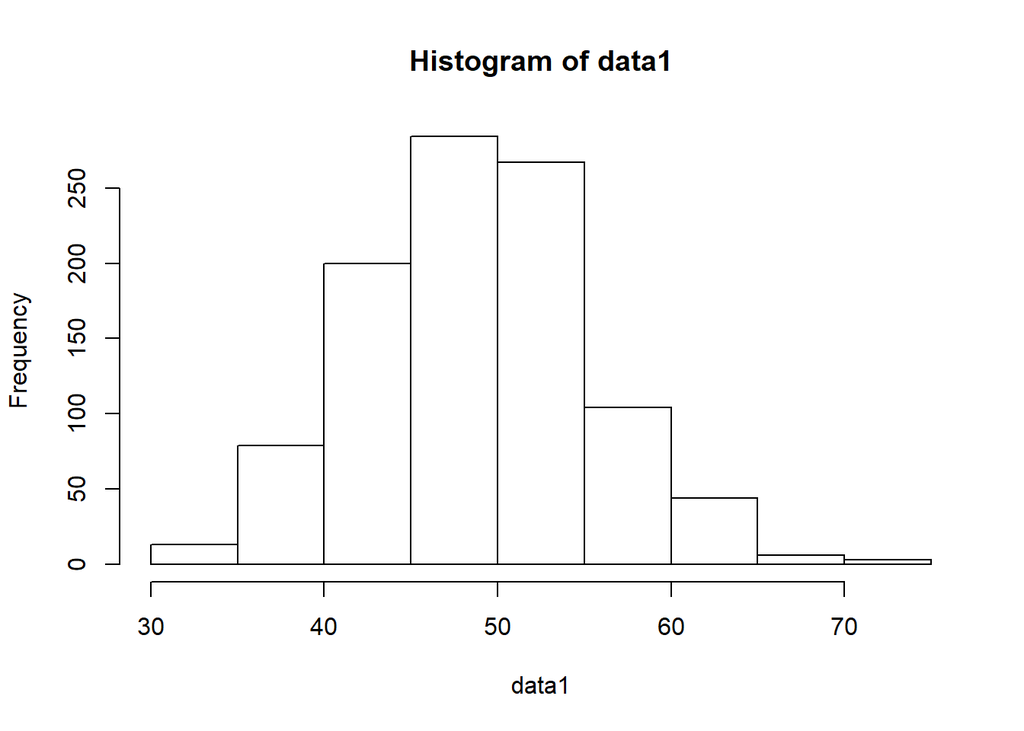

```r
data1 = rowSums(mat)
hist(data1)
```

```r
summary(data1)
```

```
##    Min. 1st Qu.  Median    Mean 3rd Qu.    Max.
##   30.00   45.00   49.00   49.22   54.00   74.00
```

### Some Stats

```r
qqnorm(data1)
qqline(data1)
```

[output not shown]

## Task 2

- Randomly pick a node and record the number of connections
- Reiterate 1000 times and plot a histogram
  - Make observations about the distribution

### Generating the Histogram of Connections

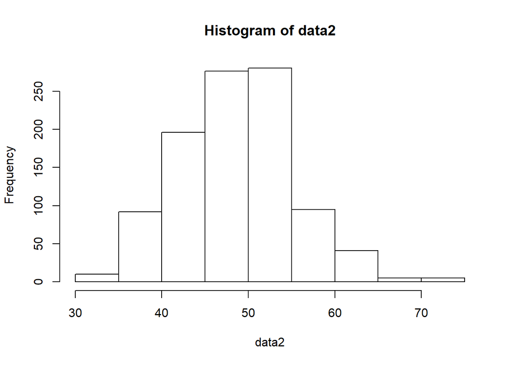

```r
data2 = vector(mode = "numeric", length = 1000)
for (i in 1:1000) {
  x = trunc(runif(1,0,1000) + 1)
  y = sum(mat[x,])
  data2[i] = y
}
hist(data2)
```

```r
summary(data2)
```

```
##    Min. 1st Qu.  Median    Mean 3rd Qu.    Max.
##   30.00   45.00   49.00   49.05   53.00   74.00
```

### Some Stats

```r
qqnorm(data1)
qqline(data1)
```

[output not shown]

## Task 3

- Generate a path starting with a random node, only moving along connections (but not backwards)
  - Move along 1000 times, but end when a node has no further connections besides the one previously traversed (highly unlikely)
- Along each node on the path, record the number of connections
- Plot a histogram
  - Make observations about the distribution

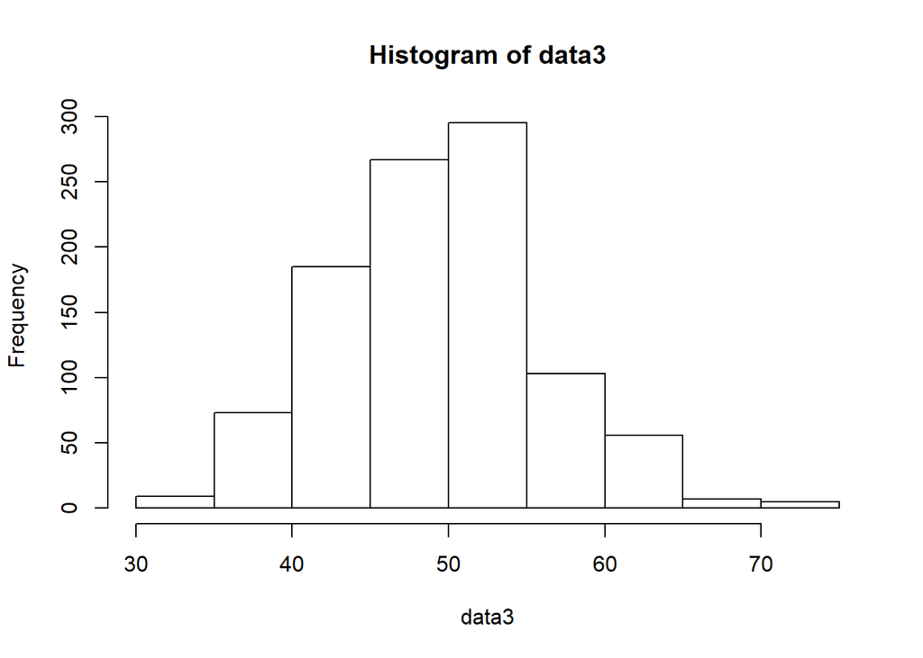

```r
data3 = vector(mode = "numeric")
start = trunc(runif(1,0,1000) + 1)
list = which(mat[start,] == 1)
back = sample(list, 1)
for (k in 1:1000) {
  node = back
  list = which(mat[node,] == 1)
  tempback = back
  while (tempback == back) {
    back = sample(list, 1)
  }
  data3 = c(data3, sum(mat[node,]))
}
hist(data3)
```

```r
summary(data3)
```

```
##    Min. 1st Qu.  Median    Mean 3rd Qu.    Max.
##   30.00   45.00   50.00   49.86   54.00   74.00
```

## Task 4

- Count the number of potential triangles in the graph

A triangle needs 3 distinct nodes, and the 3 nodes cannot be collinear (which is negligible due to dimensionality). Therefore, the number of 3 node combinations can be calculated as long as there are connections between the 3.

### Answer

```r
ans = 0
for (p in 1:1000) {
  list = which(mat[p,] == 1)
  ans = ans + (sum(mat[list,list]) / 2)
}
print(ans / 3)
```

```
## [1] 19689
```